# **Regression Trees**

Maintainer: Zhaohu(Jonathan) Fan.Contact him at (psujohnny@gmail.com)

Note: This lab note is still WIP, let us know if you encounter bugs or issues.

*Acknowledgments: I have drawn ideas or readings from the following materials:*

- [Post pruning decision trees with cost complexity pruning](https://scikit-learn.org/stable/auto_examples/tree/plot_cost_complexity_pruning.html)

### 1 CART: classification and regression trees

### 2 Regression Trees (Boston Housing Data)

- 2.1 Printing and ploting the tree
- 2.2 Prediction using regression trees

#### *Colab Notebook [Open in Colab](https://colab.research.google.com/drive/1d6PHj_B9qmLJ0RtaIpyEXI8OUu6GdpH0?usp=sharing)*

#### *Useful information about [Regression Trees in R](https://yanyudm.github.io/Data-Mining-R/lecture/6.A_RegTree.html)*

### 1 CART: classification and regression trees

CART stands for classification and regression trees:

- Regression trees: response variable Y is numerical
- Classification trees: response variable Y is categorical

For the regression trees example, we will use the Boston Housing data. Recall the response variable is the housing price. For the classification trees example, we will use the credit scoring data. The response variable is whether the loan went to default.

Note that unlike logistic regreesion, the response variable does not have to be binary in case of classification trees. We can use classification trees on classification problems with more than 2 outcomes.

### 2 Regression Trees (Boston Housing Data)

```python
import pandas as pd
import numpy as np
import sklearn
import matplotlib.pyplot as plt
import seaborn as sns
import warnings
warnings.filterwarnings("ignore")
```

### 2.1 Load Data

```python
from sklearn.preprocessing import StandardScaler
data_url = "http://lib.stat.cmu.edu/datasets/boston"
raw_df = pd.read_csv(data_url, sep="\s+", skiprows=22, header=None)
data = np.hstack([raw_df.values[::2, :], raw_df.values[1::2, :2]])
target = raw_df.values[1::2, 2]

# Updating the columns list to match the data
boston = pd.DataFrame(data, columns=["CRIM", "ZN", "INDUS", "CHAS", "NOX", "RM", "AGE", "DIS", "RAD", "TAX", "PTRATIO", "B", "LSTAT"])
boston['MEDV'] = target
boston.head()
```

|  | CRIM | ZN | INDUS | CHAS | NOX | RM | AGE | DIS | RAD | TAX | PTRATIO | B | LSTAT | MEDV |
| --- | --- | --- | --- | --- | --- | --- | --- | --- | --- | --- | --- | --- | --- | --- |
| 0 | 0.00632 | 18.0 | 2.31 | 0.0 | 0.538 | 6.575 | 65.2 | 4.0900 | 1.0 | 296.0 | 15.3 | 396.90 | 4.98 | 24.0 |
| 1 | 0.02731 | 0.0 | 7.07 | 0.0 | 0.469 | 6.421 | 78.9 | 4.9671 | 2.0 | 242.0 | 17.8 | 396.90 | 9.14 | 21.6 |
| 2 | 0.02729 | 0.0 | 7.07 | 0.0 | 0.469 | 7.185 | 61.1 | 4.9671 | 2.0 | 242.0 | 17.8 | 392.83 | 4.03 | 34.7 |
| 3 | 0.03237 | 0.0 | 2.18 | 0.0 | 0.458 | 6.998 | 45.8 | 6.0622 | 3.0 | 222.0 | 18.7 | 394.63 | 2.94 | 33.4 |
| 4 | 0.06905 | 0.0 | 2.18 | 0.0 | 0.458 | 7.147 | 54.2 | 6.0622 | 3.0 | 222.0 | 18.7 | 396.90 | 5.33 | 36.2 |

The original data are 506 observations on 14 variables, medv being the response variable y

```python
boston.shape
```

```
(506, 14)
```

```python
boston.columns
```

```
Index(['CRIM', 'ZN', 'INDUS', 'CHAS', 'NOX', 'RM', 'AGE', 'DIS', 'RAD', 'TAX',
       'PTRATIO', 'B', 'LSTAT', 'MEDV'],
      dtype='object')
```

Splitting data to training and testing samples

Next we sample 80% of the original data and use it as the training set. The remaining 20% is used as test set. The regression model will be built on the training set and future performance of your model will be evaluated with the test set.

```python
from sklearn.model_selection import train_test_split
from random import sample
import random
random.seed(1234)
```

```python
#for statmodels smf function (explained in Model Building section)
num = list(range(len(boston)))
ran = sample(num, int(len(num)*0.8))
rem = [i for i in num if i not in ran]

boston_train = boston.iloc[ran, :]
boston_test = boston.iloc[rem, :]


X_train = boston_train.iloc[:,:-1]
y_train = boston_train.iloc[:,-1:]

X_test = boston_test.iloc[:,:-1]
y_test = boston_test.iloc[:,-1:]
```

Printing and ploting the tree

```python
from sklearn.tree import DecisionTreeRegressor
from sklearn.tree import plot_tree
from sklearn import tree
clf = DecisionTreeRegressor(max_depth = 3, random_state = 0)
clf.fit(X_train, y_train)
text_representation = tree.export_text(clf, feature_names = list(X_train.columns.values))
print(text_representation)
```

```
|--- RM <= 6.92
|   |--- LSTAT <= 14.40
|   |   |--- DIS <= 1.38
|   |   |   |--- value: [45.58]
|   |   |--- DIS >  1.38
|   |   |   |--- value: [22.74]
|   |--- LSTAT >  14.40
|   |   |--- NOX <= 0.61
|   |   |   |--- value: [18.34]
|   |   |--- NOX >  0.61
|   |   |   |--- value: [12.88]
|--- RM >  6.92
|   |--- RM <= 7.44
|   |   |--- LSTAT <= 12.34
|   |   |   |--- value: [33.51]
|   |   |--- LSTAT >  12.34
|   |   |   |--- value: [12.70]
|   |--- RM >  7.44
|   |   |--- RM <= 8.75
|   |   |   |--- value: [45.87]
|   |   |--- RM >  8.75
|   |   |   |--- value: [21.90]
```

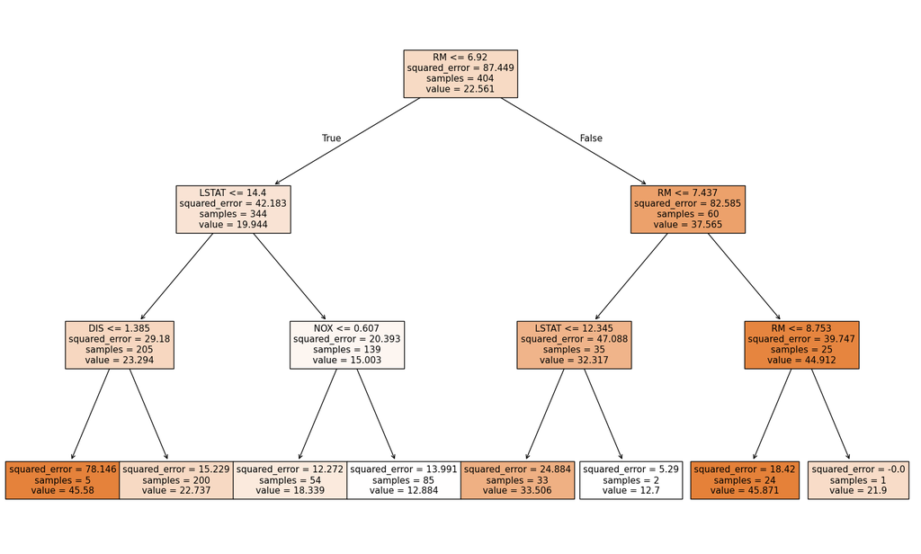

```python
fig = plt.figure(figsize=(20,12))
_ = tree.plot_tree(clf, feature_names = list(X_train.columns.values), filled=True)
```

Make sure you know how to interpret this tree model!

Prediction using regression tree The in-sample and out-of-sample prediction for regression tree is also similar linear model prediction.

In-sample prediction

```python
train_pred_tree = clf.predict(X_train)
```

Out-of-sample prediction

```python
test_pred_tree = clf.predict(X_test)
```

We often denote MSE as training error, and MSPE as testing error when sample size is large.

```python
#average sum squared errors
error = y_train['MEDV'] - train_pred_tree
AveSquErrors= (error*error).mean()
round(AveSquErrors,2)
```

```
16.24
```

```python
# Mean squared prediction error
# PrediValues is a vector that contains predicted values for test set.
test_error = y_test['MEDV'] - test_pred_tree
MSPE = (test_error*test_error).mean()
round(MSPE,2)
```

```
15.8
```

### Pruning

Refer to https://scikit-learn.org/stable/auto_examples/tree/plot_cost_complexity_pruning.html for more information.

Here we will use cost complexity pruning. Minimal cost complexity pruning recursively finds the node with the “weakest link”. The weakest link is characterized by an effective alpha, where the nodes with the smallest effective alpha are pruned first. To get an idea of what values of ccp_alpha could be appropriate, scikit-learn provides DecisionTreeRegressor.cost_complexity_pruning_path that returns the effective alphas and the corresponding total leaf impurities at each step of the pruning process. As alpha increases, more of the tree is pruned, which increases the total impurity of its leaves.

In DecisionTree, the ccp_alpha argument is one of the parameters that are used to control the compexity of the tree. It ensures that any split that does not decrease the overall lack of fit by a factor of ccp_aplha is not attempted. For a regression tree, the overall R-square must increase by ccp_aplha at each step. Basically, the smaller the ccp_aplha value, the larger (complex) tree rpart will attempt to fit.

```python
path = clf.cost_complexity_pruning_path(X_train, y_train)
ccp_alphas, impurities = path.ccp_alphas, path.impurities
```

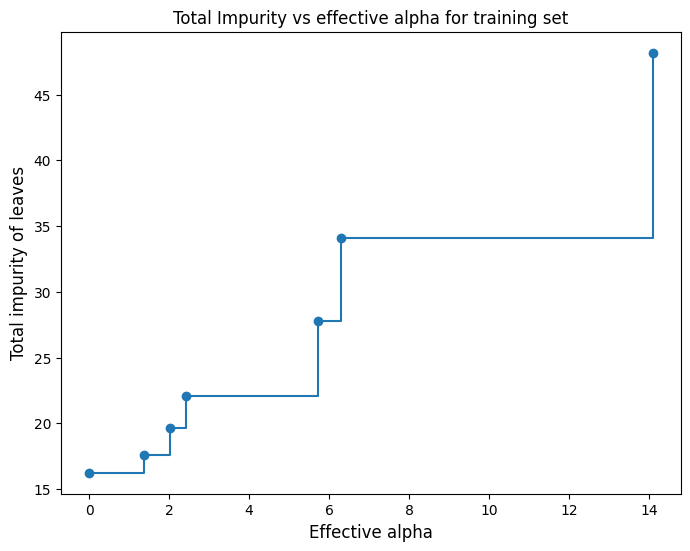

```python
plt.figure(figsize=(8,6))
plt.plot(ccp_alphas[:-1], impurities[:-1], marker='o', drawstyle="steps-post")
plt.xlabel("Effective alpha", fontsize = 12)
plt.ylabel("Total impurity of leaves", fontsize = 12)
plt.title("Total Impurity vs effective alpha for training set", fontsize = 12)
plt.show()
```

Above graph shows that as alpha increases, tree size decreases and total impurity of leaves increases

```python
from sklearn.tree import DecisionTreeRegressor
DTs = []
for ccp_alpha in ccp_alphas:
    DT = DecisionTreeRegressor(random_state=0, ccp_alpha=ccp_alpha)
    DT.fit(X_train, y_train)
    DTs.append(DT)
print("Number of nodes in the last tree is {} with ccp_alpha: {}".format(
      DTs[-1].tree_.node_count, ccp_alphas[-1]))
```

[output not shown]

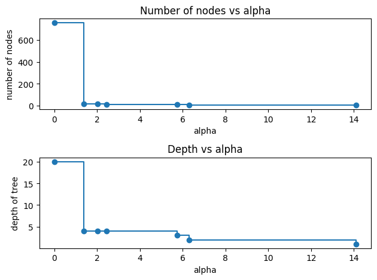

```python
DTs = DTs[:-1]
ccp_alphas = ccp_alphas[:-1]
node_counts = [DT.tree_.node_count for DT in DTs]
depth = [DT.tree_.max_depth for DT in DTs]
fig, ax = plt.subplots(2, 1)
ax[0].plot(ccp_alphas, node_counts, marker='o', drawstyle="steps-post")
ax[0].set_xlabel("alpha")
ax[0].set_ylabel("number of nodes")
ax[0].set_title("Number of nodes vs alpha")
ax[1].plot(ccp_alphas, depth, marker='o', drawstyle="steps-post")
ax[1].set_xlabel("alpha")
ax[1].set_ylabel("depth of tree")
ax[1].set_title("Depth vs alpha")
fig.tight_layout()
```

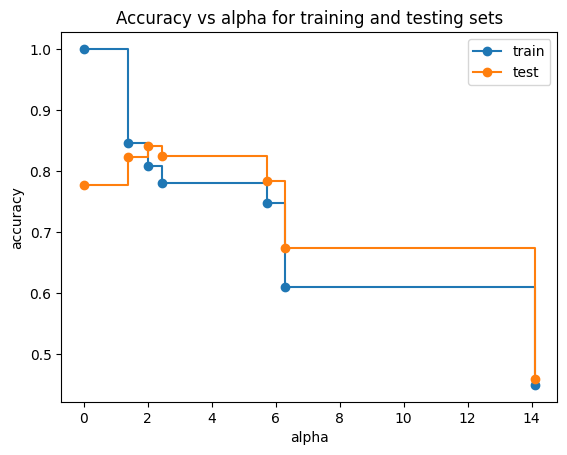

```python
train_scores = [DT.score(X_train, y_train) for DT in DTs]
test_scores = [DT.score(X_test, y_test) for DT in DTs]

fig, ax = plt.subplots()
ax.set_xlabel("alpha")
ax.set_ylabel("accuracy")
ax.set_title("Accuracy vs alpha for training and testing sets")
ax.plot(ccp_alphas, train_scores, marker='o', label="train",
        drawstyle="steps-post")
ax.plot(ccp_alphas, test_scores, marker='o', label="test",
        drawstyle="steps-post")
ax.legend()
plt.show()
```

```python
clf = DecisionTreeRegressor(ccp_alpha=1.5, min_samples_leaf=3)
clf.fit(X_train,y_train)
```

```
DecisionTreeRegressor(ccp_alpha=1.5, min_samples_leaf=3)
```

In-Sample Prediction Error (MSE)

```python
# average sum squared errors
y_pred_train = clf.predict(X_train)
#y_pred_train = pd.DataFrame({'Predicted': y_pred_train})
#y_pred_train
```

```python
error1 =np.array(y_train)- y_pred_train
MSE_insample = (error1**2).mean()
round(MSE_insample,2)
```

```
158.08
```

Out-of-Sample Prediction Error (MSPE)

```python
# mean squared prediction error (MSPE)
y_pred_test = clf.predict(X_test)
error2 = np.array(y_test) - y_pred_test
MSE_outsample = (error2**2).mean()
round(MSE_outsample,2)
```

```
134.11
```

```python
%%shell
jupyter nbconvert --to html ///content/6_A_Regression_Trees.ipynb
```